# Session III: Whole-Genome Sequencing (WGS)

armandorp@ucm.es

2021-11-05

# Whole-genome analysis of SARS-CoV 2

## 0. Reference genome of SARS-CoV 2.

WIV04 is the official reference sequence employed by GISAID. WIV04 was chosen because of its high-quality genome sequence and because it represented the consensus of a handful of early submissions for the betacoronavirus responsible for COVID-19. (Pilailuk et al 2020) WIV04 is representative of and identical to the early outbreak sequences. WIV04 was isolated by the Wuhan Institute of Virology from a clinical sample of a bronchoalveolar lavage fluid (BALF) collected at the Wuhan Jinyintan Hospital in Hubei Province on 30th December 2019 from a symptomatic patient, a retailer working at the Huanan Seafood Wholesale Market. WIV04 sequence accession in ENA browser is MN996528.1. Visit [ENA](https://www.ebi.ac.uk/ena/browser/home).

Make a directroy where you will run the pipeline

```bash
mkdir -p ~/Escritorio/GAG/GAG_WGS

cd ~/Escritorio/GAG/GAG_WGS
```

Download the reference genome of SARS-CoV2.

```bash
# Reference Genome SARS-COV2:
wget https://www.ebi.ac.uk/ena/browser/api/fasta/MN996528.1?download=true -O MN996528.1.fasta
```

## 1. Download FASTQ files of your *assigned* isolate

To start the Whole-Genome Sequencing Pipeline require to download raw data (fastq files, in paired-end) corresponding to your assigned chromosome and subgroup. Run Accession to downlaos the files are available in this [Table](https://docs.google.com/spreadsheets/d/1c9-84fDeUD9wRWQpUwlNqhP8a_rNbiMj9c31nBFlr38/edit?usp=sharing). Usually raw data are in FASTQ reads format from the Illumina platforms with a length arround 100bp and most modern assays are paired-end.

In case the ftp method is not working, visit [ENA](https://www.ebi.ac.uk/ena/browser/home) and download the selected files in ZIP following the intructions of the teacher.

```bash
# Download strain isolate ERR4780723 via FTP
# FASTQ forward
wget ftp://ftp.sra.ebi.ac.uk/vol1/...XXXXXXX_1.fastq.gz
# FASTQ reverse
wget ftp://ftp.sra.ebi.ac.uk/vol1/...XXXXXXX_2.fastq.gz
```

Sets permissions of FASTQ files so that, (U)ser / owner can read, can write and can execute. (G)roup can read, can write and can execute. (O)thers can’t read, can’t write and can’t execute.

```bash
chmod 770 *fastq.gz
```

## 2. Quality check using FastQC

We will use FastQC to check the quality of our data, this is important to figure out what kind of limitations we might have to analyse our data and the selection of parameters. Poor quality data will dramatically impact on the interpretation of data and results.

```bash
# 1-2 minute/s
# prefix="ERR4780723"
prefix="HERE YOUR RUN ACCESSION"

fastqc ${prefix}*
```

## 3. Index reference genome of SARS-CoV2 (WIV04)

We will first map the data to the SARS-CoV2 reference genome using BWA. To speed up the mapping the reference genome MUST be indexed. BWA uses an FM-Index which is built around the Burrows-Wheeler transformation.

```bash
# < 1 minute
bwa index MN996528.1.fasta
```

It is also useful to build an index of the FASTA reference file using SAMtools to allow a quick extraction of subsequences from the reference genome.

```bash
# < 1 minute
samtools faidx MN996528.1.fasta
```

## 4. Mapping reads with BWA-MEM

We will use BWA-MEM for the alignment of the processed reads to the reference genome. BWA-MEM is a fast software package for mapping low-divergent sequences against a large reference genome, such as human. So once the index has been built we can map the paired-end FASTQ data against the reference and convert it to BAM.

```bash
# 1-2 minutes
bwa mem MN996528.1.fasta ${prefix}_1.fastq.gz ${prefix}_2.fastq.gz -o ${prefix}.sam
```

Transform and sort SAM files into BAM files

```bash
# 1 minute
samtools view -o ${prefix}.bam -Shb ${prefix}.sam

head ${prefix}.sam
```

Have a look into the generated bam file to check its contents. You can read it using **samtools**

```bash
# 1 minute
samtools view ${prefix}.bam | head
```

We use samtools to sort by coordinates our bam file, and we build a new bam file.

```bash
# 1 minute
samtools sort ${prefix}.bam -o ${prefix}.sorted.bam

samtools index ${prefix}.sorted.bam
```

## 5. Mark Duplicates and Alignment Quality Control

Unless you are using a PCR-free library, PCR duplicates are common in DNA-sequencing and should be flagged prior to variant calling.

```bash
# 2 minutes
picard MarkDuplicates INPUT=${prefix}.sorted.bam OUTPUT=${prefix}.dedup.sorted.bam METRICS_FILE=${prefix}_metrics.txt REMOVE_DUPLICATES=true
```

## 6. Variant Calling

```bash
# 1-2 minutes

bcftools mpileup -Ou -f MN996528.1.fasta ${prefix}.dedup.sorted.bam | bcftools call --ploidy 1 -Oz -m -v -o ${prefix}.vcf.gz

bcftools index ${prefix}.vcf.gz
```

## 7. Get the FASTA sequence of the isolate

```bash
cat MN996528.1.fasta | bcftools consensus ${prefix}.vcf.gz > ${prefix}.fasta
```

## 8. Explore the VCF file

```bash
gunzip ${prefix}.vcf.gz

# Check contents
head -n 100 ${prefix}.vcf

# Count the number of variants
wc -l ${prefix}.vcf

bcftools query -f '[%CHROM\t%POS\t%REF\t%ALT\t%SAMPLE\t%GT\n]' ${prefix}.vcf > ${prefix}_isolate_alleles.txt
```

## 9. Visualize your alignement with IGV

Integrative Genomics Viewer (IGV) is a high-performance, easy-to-use, interactive tool for the visual exploration of genomic data. Run IGV in the terminal, load the reference genome in FASTA format and load the BAM file of sorted coordinates ${prefix}.sorted.bam file.

```bash
# RUN IGV program
igv
```

## 10. Clade identification of your isolate

To explore the clade of your virus strain check your mutations and take into account phylogenetic relationships between SARS-CoV2 clades. Check “clade_variants.txt” file to get the clade-specific variants to identify your isolate.

```r
clades.variants <- read.table(file = "https://www.dropbox.com/s/s7kelho27f0g5dt/clade_variants.txt?dl=1", header = T, sep = "\t")
```

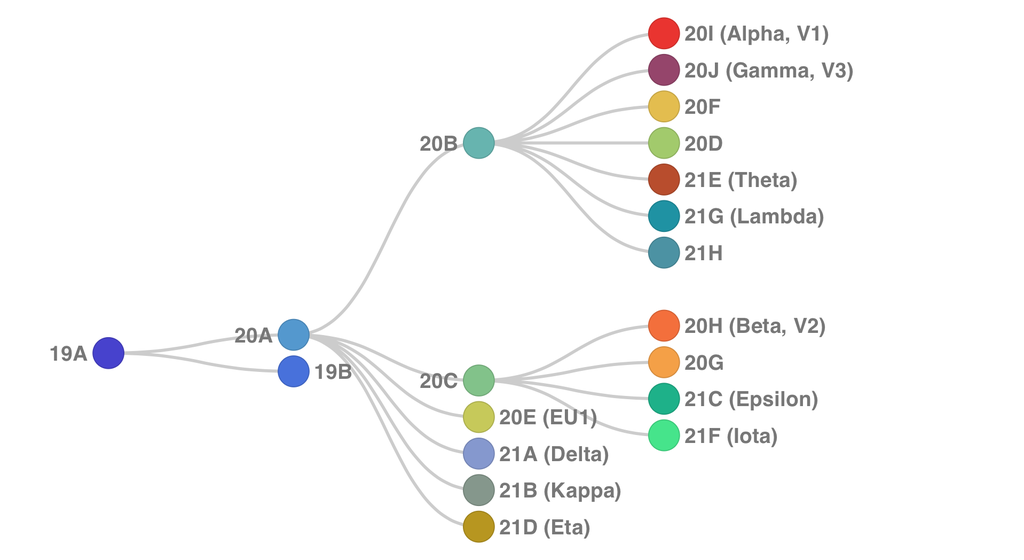

You can also check virus mutations of your isolate overlapping known SARS-CoV ORFs.

```r
gene_annotation <- read.table(file = "https://www.dropbox.com/s/16bm9vxkbzw9559/gene_annotation_SARS_CoV2.gff?dl=1", header = T, sep = "\t")
```

## Homeworks

**Note:** Keep in mind that you will need VCF (or “isolate_alleles.txt”) files in order to solve exercises.

> **Exercise 1:** How many genetic variants were detected in the SARS-CoV 2 strain of your isolate (run accession assigned to you) after running the WGS pipeline?

> **Exercise 2:** How many Guanines are in all alternative alleles of the genetic variants detected by comparing your WGS of your isolate to the reference genome?

> **Exercise 3:** Identify the corresponding clade of your isoalte using information of their phylogenetic relationships and the clade-specific variants that are available in the file clades_variants.txt.

```r
clades.variants <- read.table(file = "https://www.dropbox.com/s/s7kelho27f0g5dt/clade_variants.txt?dl=1", header = T, sep = "\t")
```

> **Exercise 4:** Which is the position of the last alternative variant detected in your analysis compared to the reference genome of SARS-CoV 2?

> **Exercise 5:** How many variants overlap with SARS-CoV-2 genes? Use the gene_annotation_SARS_CoV2.gff file to determine the overlaps between detected mutations and ORFs.

```r
gene_annotation <- read.table(file = "https://www.dropbox.com/s/16bm9vxkbzw9559/gene_annotation_SARS_CoV2.gff?dl=1", header = T, sep = "\t")
```